# MATH1062 Statistics

Lab Week 3 - Graphical and numerical summaries

Author

Kierin Chung with scaffold and instructions from Yeeka Yau.

Published

August 18, 2025

## Welcome to Week 3! ✈️

In this week’s lab we will get hands on practice with computing and visualising numerical summaries in R. By the end of this lab, you should be able to make comparative box plots to explore two numerical variables across different factors in a categorical variable and be able to write your own functions in R!

### Learning Outcomes covered in this lab

- **LO3**. identify appropriate methods to describe, summarise and visualise a given data set
- **LO5**. apply statistical software such as R to analyse example sets of data

### Specific lab outcomes:

- Make more new friends and have more fun.
- Practice statistical thinking with numerical variables, and develop a sense of when different measures of centre and spread are appropriate.
- Be able to use R to calculate basic numerical summaries and make basic data visualisations, in particular, boxplots.
- Learn how to write basic functions in R to compute numerical summaries.

## Group Discussion Questions

1. To quickly review the content from week 2, in your groups, discuss: What’s the difference between **IQR** and **standard deviation**? **Write this on the board**.

IQR is the range between the top and bottom of the middle 50% of the data. It is robust to outliers. Standard Deviation is the square root variance between data, ie, how much the data varies from the mean. It is not robust to outliers.

2. Also discuss: Why is the z-score *unit-free*? How does this make it useful for comparing variables measured in different units? **Write this on the board**.

z-score is the amount of standard deviations away a certain give value is from the dataset. It is useful for comparing variables in different scenarios as it allows you to see how each value varies from the mean and how much it varies based upon std deviation.

### Import packages

```r
library(tidyverse)
```

### The data set

This week, we examine a data set of **NYC flight data** from the `nycflights13` package (see https://github.com/tidyverse/nycflights13). This data set contains information on all flights that departed from New York City airports (these are abbreviated as EWR, JFK and LGA) to destinations in the United States, Puerto Rico, and the American Virgin Islands) in 2013: 336,776 flights in total. We will just work with a subset of 2000 observations of the data.

```r
# Read in the data from the nycflights_sample csv file into the variable flights_sample
flights_sample <- read.csv('/Users/kierin/MATH1062/Week3/nycflights_sample.csv')
```

#### View a “summary” of the data with the `str()` function

```r
str(flights_sample)
```

```
'data.frame':   2000 obs. of  19 variables:
 $ year          : int  2013 2013 2013 2013 2013 2013 2013 2013 2013 2013 ...
 $ month         : int  5 3 2 4 6 2 5 10 11 9 ...
 $ day           : int  1 2 19 1 12 19 7 21 12 10 ...
 $ dep_time      : int  1942 1607 1332 1423 846 2330 600 1639 852 1007 ...
 $ sched_dep_time: int  1943 1610 1335 1426 840 2129 600 1642 900 1015 ...
 $ dep_delay     : int  -1 -3 -3 -3 6 121 0 -3 -8 -8 ...
 $ arr_time      : int  2134 1717 1918 1643 1146 31 828 1830 1216 1111 ...
 $ sched_arr_time: int  2100 1800 1929 1653 1139 2245 835 1837 1157 1129 ...
 $ arr_delay     : int  34 -43 -11 -10 7 106 -7 -7 19 -18 ...
 $ carrier       : chr  "EV" "AA" "UA" "DL" ...
 $ flight        : int  3267 341 15 1705 443 4210 517 1365 27 6181 ...
 $ tailnum       : chr  "N13949" "N469AA" "N77066" "N343NW" ...
 $ origin        : chr  "EWR" "LGA" "EWR" "LGA" ...
 $ dest          : chr  "PWM" "ORD" "HNL" "MSY" ...
 $ air_time      : int  54 106 617 182 326 45 130 94 148 40 ...
 $ distance      : int  284 733 4963 1183 2475 266 937 488 937 212 ...
 $ hour          : int  19 16 13 14 8 21 6 16 9 10 ...
 $ minute        : int  43 10 35 26 40 29 0 42 0 15 ...
 $ time_hour     : chr  "2013-05-01 19:00:00" "2013-03-02 16:00:00" "2013-02-19 13:00:00" "2013-04-01 14:00:00" ...
```

We will use this data set to explore aspects of flight delays.

## Boxplots

3. Make a **boxplot** of `arr_delay`, using **ggplot** and the `geom_boxplot()` option (try to follow the same code structure as the examples from the previous weeks). In your groups, describe the distribution of delays.

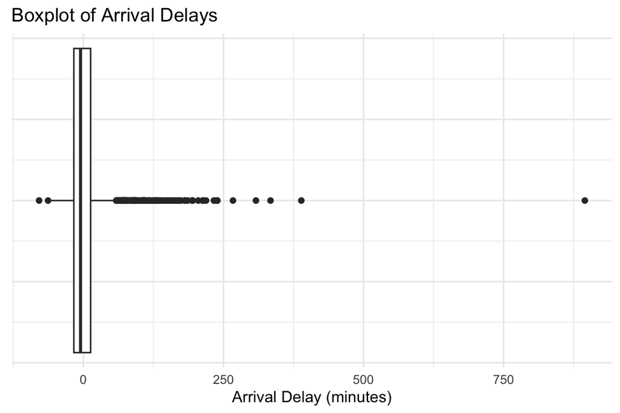

```r
library(ggplot2)

ggplot(data = flights_sample, aes(x = arr_delay)) +
  geom_boxplot() +
  labs(
    title = "Boxplot of Arrival Delays",
    x = "Arrival Delay (minutes)"
  ) +
  theme_minimal() +
  theme(
    axis.text.y = element_blank(),   # Remove x-axis text
    axis.ticks.y = element_blank()   # Remove x-axis ticks
  )
```

**Description of the distribution:**

The distribution is centered around 0 minutes with Q3 at approx less 1 hour. There are lots of outliers, specifically above, with some data being outliers prima facie their delay.

4. What would be the most appropriate measure of **centre** and **spread** for the `arr_delay` variable?

Median and IQR.

5. The IQR is a little difficult to see from the boxplot. Compute the **IQR** of `arr_delay` then use this to work out the value of the **lower** and **upper thresholds** (LT and QT) of the boxplot. Report the appropriate measure of **centre** and **spread.**  
   *(Hint: Use the IQR rules:* $Q1 - 1.5 \times IQR$ and $Q3 + 1.5 \times IQR$. Q1 and Q3 have been computed for you.)

```r
# Q1 and Q3
Q1 <- as.numeric(quantile(flights_sample$arr_delay, probs = 0.25))
Q3 <- as.numeric(quantile(flights_sample$arr_delay, probs = 0.75))

# Your code here to compute the IQR

IQR <- Q3 - Q1

# Compute the upper and lower Thresholds

Upper <- Q3 + 1.5 * IQR
Lower <- Q1 - 1.5 * IQR

# Compute the median

Median <- median(flights_sample$arr_delay)

# Print the IQR, LT, UT and median

library(glue)

summary_string <- glue(
  "IQR: {round(IQR, 2)} | ",
  "Lower: {round(Lower, 2)} | ",
  "Upper: {round(Upper, 2)} | ",
  "Median: {round(Median, 2)}"
)

print(summary_string)
```

```
IQR: 30 | Lower: -62 | Upper: 58 | Median: -5
```

**Answer** IQR: 30 | Lower: -62 | Upper: 58 | Median: -5

6. Create a **comparative** **boxplot** of `arr_delay` by `carrier` (airline) to discuss and answer the following questions in your groups (see the code example from last week’s lecture).

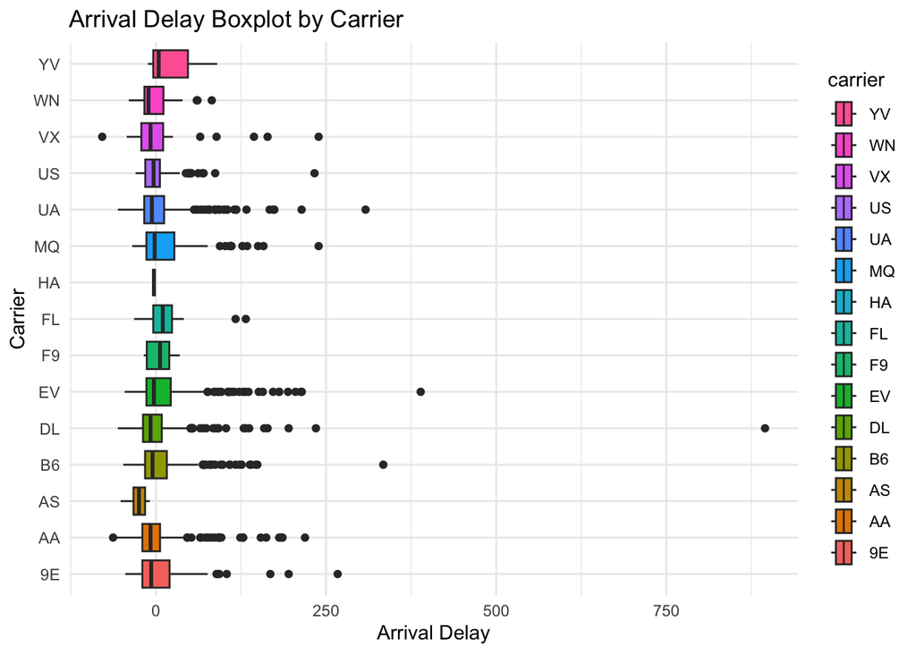

```r
ggplot(flights_sample, aes(x=arr_delay, y = carrier, fill = carrier)) +
  geom_boxplot() +
  labs(title = 'Arrival Delay Boxplot by Carrier', x = 'Arrival Delay', y = 'Carrier') +
  theme_minimal() +
  guides(fill = guide_legend(reverse = TRUE))
```

- **Which airline has the most variation in arrival delays?**

  YV; Mesa Airlines.
- **Which airlines have outliers with very large delays?**

  DL; Delta EV; Eva Airways B6; JetBlue Airlines UA; United Airlines
- **If you were to choose an airline purely based on reliability of arrival times, which would you choose? Why?**

  AS or HA seem the most reliable. AS; Alaska Airlines HA; Hawaian Airlines Perhaps even WN: Southwest Airlines.
7. Compute the **sample standard deviation** of `arr_delay` for `flights_sample` using `sd()`.

```r
sd(flights_sample$arr_delay)
```

```
[1] 46.8849
```

## Introduction to Writing Functions in R

In R, functions are one of the most powerful tools you’ll use.  
You’ve already seen many built-in functions, like `mean()`, `median()`, and `sd()`.

A **function** is simply a way to:

- **Take some input** (called *parameters,* don’t confuse this with population parameters)
- **Do some work** (run a series of commands)
- **Return an output**.

### Creating Your Own Functions

We can write our own functions in R using the `function()` keyword.  
**The basic structure is:**

```r
# Your code here
function_name <- function(parameter1, parameter2){
  # Do something with the parameters
  c <- parameter1 + parameter2 # example calculation
  return(c) # send the result back
  }
```

### The power of R

In R, many operations are *vectorized*. This means that if you perform a calculation on a vector (a list of numbers or a column/variable in your dataset), R automatically applies that calculation to **each element** of the vector. This is one of the reasons R is so concise — you can write one short expression and have it work for an entire dataset.

```r
# Example: Adding 5 to each element of a vector
numbers <- c(2, 4, 6, 8)

# Vectorized operation: add 5 to every element
new_numbers <- numbers + 5

# Display the result
new_numbers
```

```
[1]  7  9 11 13
```

In this section we will practice writing our own functions! *Do not worry if you can’t get this right away. There are a lot of fiddly things in programming that can only be worked out with experience (some idiosyncrasies you just won’t know as a beginner, which can be frustrating). Just try your best and the teaching team will help you if you have questions.*

8. Write your own function for computing the **population SD**: $\sigma = \sqrt{\frac{1}{N} \sum_{i=1}^N (x_i - \mu)^2}$, do this without using the `sd()` function. Call this function `pop_sd`.

```r
pop_sd <- function(x){
  N <- length(x)
  mean <- mean(x)
  val <- 0
  for (i in 1:N) {
    calc_val <- (x[i] - mean)^2
    val <- val + calc_val
  }
  sigma <- ((1/N) * val)^(1/2)
  return(sigma) # Change the 0 in return() to what should be returned from your function
}
```

9. Use your `pop_sd` function to calculate the population standard deviation of `arr_delay` for `flights_sample` treating these observations as if it was a population.

```r
pop_sd(flights_sample$arr_delay)
```

```
[1] 46.87318
```

10. Recall that “standard units” allow us to compare a numerical variable for different groups in terms of standard deviations. Write your own function `z_score()` that takes a vector `x` and returns a vector of z-scores.  
    (*Hint:* Use `mean()` and `sd()` inside your function.)

```r
# Your code here
z_score <- function(x){
  mean <- mean(x)
  sd <- sd(x)
  z <- ((x-mean)/sd)

  return(z)
}
```

Here we create a new column in `flights_sample` called `arr_delay_z_score` by applying your `z_score` function to the `arr_delay` variable. Just read the code and run it. You’ll need to scroll to the right of the table to see the `arr_delay_z_score` column.

```r
#  Create a new column called arr_delay_z_score with the mutate() function
flights_sample %>%
  mutate(arr_delay_z_score = z_score(arr_delay)) ->
  flights_sample #save it back into the flights_sample variable

print(head(flights_sample))
```

```
  year month day dep_time sched_dep_time dep_delay arr_time sched_arr_time
1 2013     5   1     1942           1943        -1     2134           2100
2 2013     3   2     1607           1610        -3     1717           1800
3 2013     2  19     1332           1335        -3     1918           1929
4 2013     4   1     1423           1426        -3     1643           1653
5 2013     6  12      846            840         6     1146           1139
6 2013     2  19     2330           2129       121       31           2245
  arr_delay carrier flight tailnum origin dest air_time distance hour minute
1        34      EV   3267  N13949    EWR  PWM       54      284   19     43
2       -43      AA    341  N469AA    LGA  ORD      106      733   16     10
3       -11      UA     15  N77066    EWR  HNL      617     4963   13     35
4       -10      DL   1705  N343NW    LGA  MSY      182     1183   14     26
5         7      UA    443  N596UA    JFK  LAX      326     2475    8     40
6       106      EV   4210  N12142    EWR  BTV       45      266   21     29
            time_hour arr_delay_z_score
1 2013-05-01 19:00:00       0.580986578
2 2013-03-02 16:00:00      -1.061333086
3 2013-02-19 13:00:00      -0.378810628
4 2013-04-01 14:00:00      -0.357481802
5 2013-06-12 08:00:00       0.005108254
6 2013-02-19 21:00:00       2.116662107
```

Which flight (in `flights_sample`) has the **highest z-score** for `arr_delay`? Here we use the `sort_by()` function. You’ll need to scroll to the right of the table to see the `arr_delay_z_score` column.

```r
# Run this code
sort_by(flights_sample, flights_sample$arr_delay_z_score, decreasing = TRUE)
```

```
     year month day dep_time sched_dep_time dep_delay arr_time sched_arr_time
1504 2013     7  22     2257            759       898      121           1026
1456 2013     7  11     1309            620       409     1446            817
762  2013     7  10     2109           1635       274      112           1938
890  2013    12  11     1915           1524       231     2350           1842
712  2013     8  16     1242            745       297     1427           1000
954  2013     6   3     1303            910       233     1509           1110
1703 2013     7  28     2107           1729       218       54           2055
1674 2013     7  10     2146           1800       226        7           2012
1915 2013     6  24     2300           1900       240        5           2012
708  2013     4  19     2313           1930       223      209           2230
547  2013     4  17     2147           1800       227     2318           1944
1426 2013     6  10     2235           1945       170      123           2149
1428 2013     3  24     2252           1906       226       13           2039
1861 2013     3  10       41           2100       221      230           2257
```

[output cut: 5988 more lines]

In this example, flight DL2047 had the highest z-score. It was over 18 standard deviations above the average in lateness.